# Frecuency consultation for neurodevelopmental disorders in Colombia - Total cases

Data analysis notebook

Author

Affiliation

Daniel Manrique-Castano, PhD

Digital Research Alliance of Canada

Published

Tuesday, November 4, 2025

Keywords

Epidemiology, Neuropsychology, Mental healh, Colombia

# 1 Load Project Setup

# 2 Consultations per year

In this section, we explore the frequency of consultations for neurodevelopmental disorders per year in Colombia.

## 2.1 Data Preparation

First, we create a summary table by grouping the main Neuro_Data by Year and summing all Cases for each year.

```r
Summary_year <- Neuro_Data %>%
  group_by(Year) %>%
  summarise(Total_Cases = sum(Cases, na.rm = TRUE)) %>%
  ungroup()

Summary_year
```

```
# A tibble: 7 × 2
   Year Total_Cases
  <int>       <int>
1  2016      154453
2  2017      194102
3  2018      231242
4  2019      332318
5  2020      179859
6  2021      240548
7  2022      283661
```

## 2.2 Data visualization

We visualize the yearly trend using a line and point plot. The y-axis labels are formatted with scales::cut_short_scale() to automatically display “K” for thousands.

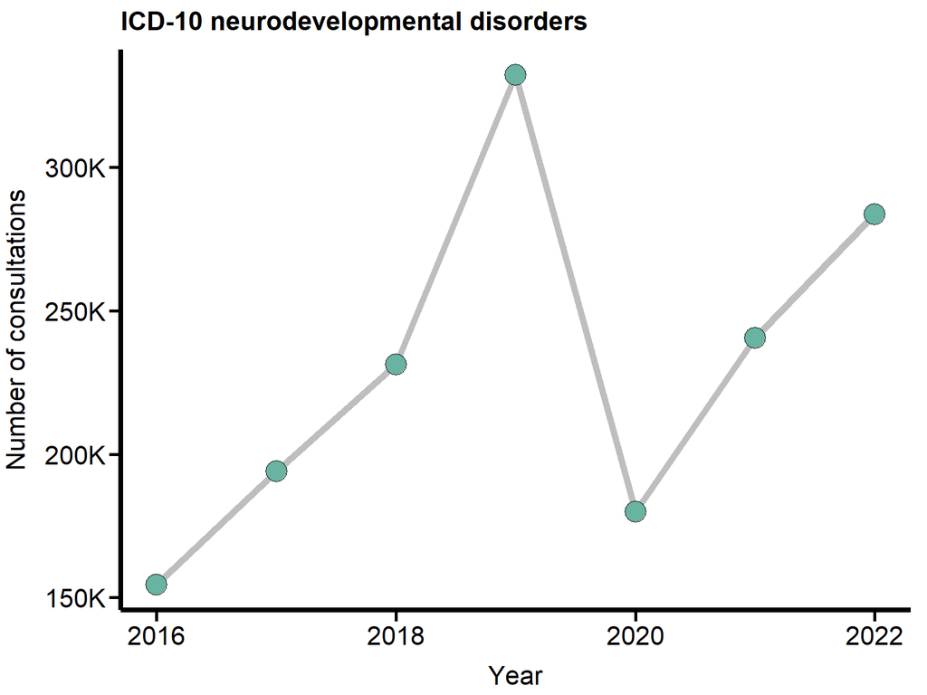

Figure 1: Distribution of neurodevelopmental disorder cases per year

```r
Cases_Year_fig <- Summary_year %>%
  ggplot( aes(x= Year, y=Total_Cases)) +
    geom_line( color="grey", linewidth= 2) +
    geom_point(shape=21, color="black", fill="#69b3a2", size=6) +
    scale_y_continuous(name = expression ("Number of consultations"),
                     labels = scales::label_number(scale_cut = scales::cut_short_scale())) +
    ggtitle("ICD-10 neurodevelopmental disorders") +
    labs(x = "Year") +
    Plot_theme

ggsave(Cases_Year_fig,
       filename = "Plots/Cases_Year_fig.png",
       width    = 14,
       height   = 12,
       units    = "cm")

Cases_Year_fig
```

# 3 Geographical distribution

Now, we will generate an illustrative geographical map showcasing the number of consultations by department.

## 3.1 Data Preparation

We group the data by Department and sum all Cases. This Summary_Department data frame will be used for both the table and the map.

```r
Summary_Department <- Neuro_Data %>%
  group_by(Department) %>%
  summarise(TotalCases = sum(Cases, na.rm = TRUE)) %>%
  ungroup()
```

## 3.2 Results Table

For clarity, we present a publication-ready table of cases per department. The table is formatted using gt to follow APA 7th edition guidelines, including horizontal rules and comma-separated numbers for readability.

```r
# Sort data for the table
department_table_data <- Summary_Department %>%
  arrange(desc(TotalCases))

# Create the gt table
department_table <- department_table_data %>%
  gt() %>%
  cols_label(
    Department = "Department",
    TotalCases = "Total Cases"
  ) %>%
  fmt_number(
    columns = TotalCases,
    use_seps = TRUE,
    decimals = 0
  ) %>%
  tab_options(
    table.border.top.width = px(2),
    table.border.top.color = "black",
    table.border.bottom.width = px(2),
    table.border.bottom.color = "black",
    column_labels.border.bottom.width = px(2),
    column_labels.border.bottom.color = "black",
    table_body.border.top.style = "none",
    table_body.border.bottom.style = "none",
    table.border.left.style = "none",
    table.border.right.style = "none",
    table_body.vlines.style = "none",
    column_labels.vlines.style = "none"
  )

# Save the table files
gtsave(department_table,
       filename = "Tables/Department_Summary_Table.html")
gtsave(department_table,
       filename = "Tables/Department_Summary_Table.tex")

department_table
```

Table 1: Total Cases by Department

| Department | Total Cases |
| --- | --- |
| Cundinamarca | 463,377 |
| Antioquia | 158,367 |
| Atlantico | 145,524 |
| Valle del Cauca | 118,655 |
| Bolivar | 84,555 |
| Santander | 81,847 |
| Narino | 60,805 |
| Norte de Santander | 47,460 |
| Cordoba | 45,376 |
| Caldas | 42,899 |
| Cauca | 37,571 |
| Sucre | 36,946 |
| Huila | 34,864 |
| Risaralda | 34,602 |
| Tolima | 32,379 |
| Cesar | 29,630 |
| Boyaca | 26,616 |
| Magdalena | 25,937 |
| Meta | 22,465 |
| La Guajira | 18,948 |
| Quindio | 18,392 |
| Casanare | 12,863 |
| Caqueta | 11,178 |
| Putumayo | 9,004 |
| Arauca | 6,388 |
| Choco | 5,521 |
| Archipielago de San Andres, Providencia Y Santa Catalina | 1,209 |
| Guaviare | 1,149 |
| Amazonas | 890 |
| Vichada | 326 |
| Guainia | 292 |
| Vaupes | 148 |

## 3.3 Generating a map of Colombia

To join the case data with the map geometry, we use the Col_map_fixed object (loaded from _common.R) and perform a left_join with our Summary_Department data.

```r
Map_df <- Col_map_fixed %>%
  left_join(Summary_Department, by = "Department")
```

## 3.4 Consultation by Department

We plot the total number of cases by department. To highlight the most-affected regions, we create a top_5_data subset and use geom_sf_text to overlay their labels on the map. The fill scale is square-root-transformed (trans = “sqrt”) to better visualize the distribution, and labels are formatted to “K” for thousands.

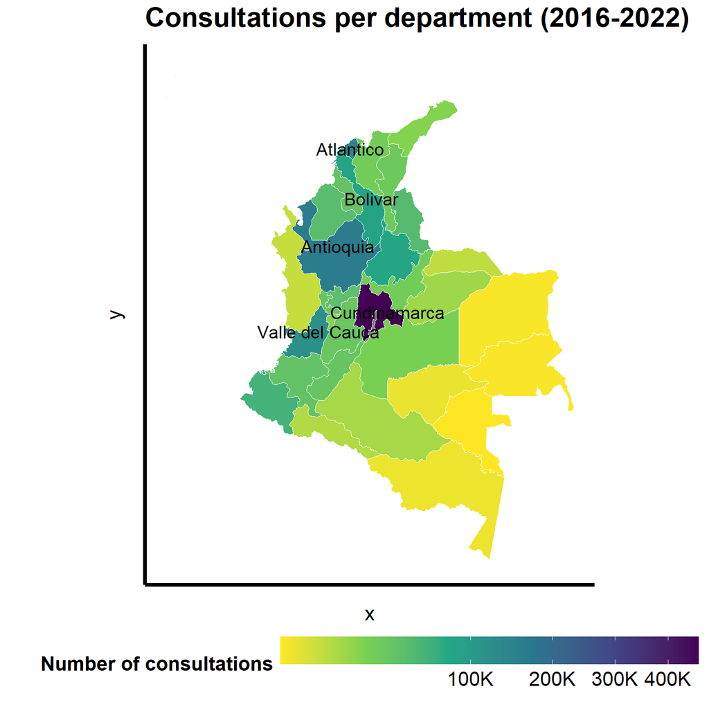

```r
# Create a data frame for the top 5 labels
top_5_data <- Map_df %>%
  slice_max(order_by = TotalCases, n = 5)

# Create the map
Department_map <- ggplot(Map_df) +
  geom_sf(aes(fill = TotalCases), colour = "white", size = 0.2) +

  # Add the text labels for the top 5
  geom_sf_text(
    data = top_5_data,
    aes(label = Department),
    color = "black",
    size = 5,
    check_overlap = TRUE
  ) +

  scale_fill_viridis_c(
    option    = "viridis",
    direction = -1,
    trans     = "sqrt",
    name      = "Number of consultations",
    labels    = function(x) { sprintf("%.0fK", x / 1000) },
    guide = guide_colorbar(
      barwidth     = unit(12, "cm"),
      barheight    = unit(0.8, "cm")
    )
  ) +
  labs(title = "Consultations per department (2016-2022)") +
  theme_minimal() +
  Plot_theme +
  theme(
    plot.title = element_text(size=22, face="bold", vjust = 2),
    axis.text.y = element_blank(),
    axis.text.x = element_blank(),
    axis.ticks.y = element_blank(),
    axis.ticks.x = element_blank(),
    legend.position = "bottom",
    legend.direction = "horizontal",
    legend.title = element_text(colour="black", face="bold", size=16),
    legend.text = element_text(colour="black", size=16),
    strip.text = element_text(size = 20)
  )

ggsave(Department_map,
       filename = "Plots/Department_map.png",
       width    = 20,
       height   = 25,
       units    = "cm")

Department_map
```

## 3.5 Consultations conditional on capital city

To analyze the effect of urbanicity, we compare capital vs. non-capital cities. First, we calculate a new variable, Diagnostics_per_thousand. We then group by Capital and Department status to find the median cases for each.

```r
Neuro_Data2 <- Neuro_Data %>%
  mutate(Diagnostics_per_thousand = round((Cases / Population) * 10000))

Summary_Capital <- Neuro_Data2 %>%
  group_by(Capital, Department) %>%
  summarise(
  Median_Cases_Capitals = median(Diagnostics_per_thousand, na.rm = TRUE),
  ) %>%
  ungroup()
```

### 3.5.1 Data Visualization

We use a ridge plot (ggridges) to visualize the distribution of median consultation rates, comparing capital and non-capital departments. To make the plot more informative, we pre-calculate the Median and SD for each group and overlay this text directly onto the plot using geom_text.

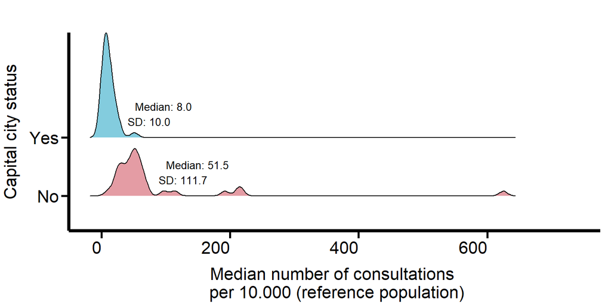

Figure 3: Distribution of median neurodevelopmental diagnostic cases by capital status, with summary statistics.

```r
library(ggridges) # For the ridge plot
library(dplyr)    # For calculating the stats

# --- 1. Create the summary statistics data frame ---
# We calculate the median and SD for each 'Capital' group
stats_data <- Summary_Capital %>%
  group_by(Capital) %>%
  summarise(
    Median = median(Median_Cases_Capitals, na.rm = TRUE),
    SD = sd(Median_Cases_Capitals, na.rm = TRUE)
  ) %>%
  ungroup() %>%
  # Create a text label with line breaks (\n)
  mutate(
    summary_label = sprintf("Median: %.1f\nSD: %.1f", Median, SD)
  )

# --- 2. Create the plot ---
Cases_Capital_fig <- Summary_Capital %>%
  ggplot(aes(x = Median_Cases_Capitals, y = Capital, fill = Capital)) +

  # Draw the ridges
  geom_density_ridges(alpha = 0.7) +

  # --- 3. Add the summary text ---
  # We use the new 'stats_data' data frame
  # inherit.aes = FALSE stops it from interfering with the main plot
  geom_text(
    data = stats_data,
    inherit.aes = FALSE,
    # Place text at the Median (x) and on the correct Capital ridge (y)
    aes(x = Median, y = Capital, label = summary_label),
    color = "black",  # Text color
    size = 3.5,       # Text size
    vjust = -0.5,     # Vertical justification (move text *up*)
    hjust = -0.5         # Horizontal justification (start text at the median)
  ) +

  ggtitle("") +

  scale_fill_manual(
    name = "Capital city",
    values = c("#D9717D", "#4DB6D0"),
    labels = c("No", "Yes")
  ) +

  labs(y = "Capital city status",
       x = "Median number of consultations \n per 10.000 (reference population)") +

  # Widen the x-axis to make room for the text
  scale_x_continuous(expand = expansion(mult = c(0.05, 0.2))) +

  Plot_theme +
  theme (legend.position = "none",
         axis.text.x = element_text(hjust = 1))

ggsave(Cases_Capital_fig,
       filename = "Plots/Cases_Capital_fig.png",
       width    = 14,
       height   = 12,
       units    = "cm")

Cases_Capital_fig
```